# circos

sunjianjian

2026-02-03

```r
library(DiagrammeR)
mermaid("
graph TD
    A[\"原始输入 data.txt\"] -->|清洗 & 格式化| B(\"临时 VCF 文件\")
    C[\"骨架文件 chrom_sizes.txt\"] -->|提取病毒信息| B

    %% 这里加了转义引号 \"...\"，这样里面的括号就不会报错了
    B -->|VariantAnnotation| D[\"GInteractions 对象(便于储存病毒整合事件)\"]

    D -->|转换为 Data Frame| E[\"绘图就绪数据\"]
    E -->|智能修正| F{\"染色体命名对齐?\"}
    F -->|No| G[\"自动添加/移除 chr 前缀\"]
    F -->|Yes| H[\"进入绘图循环\"]
    G --> H

    %% 连接线文字太长或含特殊符号时，也建议加引号
    H -->|\"读取 layout_list(用户可自定义圈层位置)\"| I[\"动态渲染轨道\"]
    I --> J((\"输出 Result.pdf\"))

    style A fill:#e1f5fe,stroke:#01579b
    style C fill:#e1f5fe,stroke:#01579b
    style B fill:#fff9c4,stroke:#fbc02d
    style D fill:#fff9c4,stroke:#fbc02d
    style J fill:#e8f5e9,stroke:#2e7d32
")
```

[interactive chart not shown]

## 输入输出：

1.首先需要输入变异位点的数据信息data.txt。也就是vcf文件（用于存储基因组中的遗传变异数据）,然后转换为gi对象便于内部储存调用，最后输出为circos图。

2.其次需要输出宿主和病毒的长度信息，便于染色体层的绘制。

3.用户可以选择提供color_file对不同的染色体进行绘制，不提供则默认为彩虹色

4.用户需要输入一个布局信息，我希望用户不是只能够绘制固定的染色体层–散点层–线层，用户可以自己决定圈层的宽度，添加更多的信息，所以用户再使用前应该先自定义一个layout_list布局，用于决定绘制的顺序，也方便后续添加别的图层。比如：

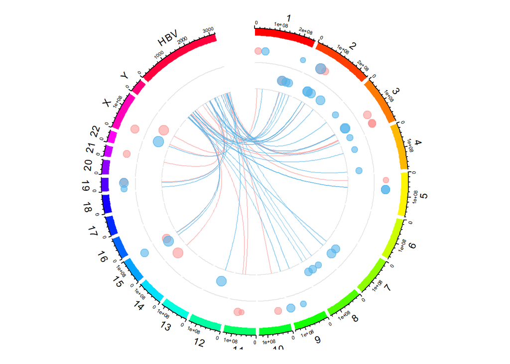

```r
# 绘制染色体层--散点层--线层
library(ViHostPlot)
layout1 <- list(
  list(type = "ideogram", height = 0.05),
  list(type = "scatter", sample_label = "T", height = 0.15),
  list(type = "scatter", sample_label = "N", height = 0.15),
  list(type = "links")
)

data_path <- system.file("extdata", "data.txt", package = "ViHostPlot")
host_path <- system.file("extdata", "chrom_sizes.txt", package = "ViHostPlot")

p1 <- visualize_viral_integration(
  input_file = data_path,
  host_file = host_path,
  output_file = NULL,
  layout_list = layout1
)
```

再比如：

```r
# 绘制线层--染色体层--散点层
layout2 <- list(
  list(type = "scatter", sample_label = "T", height = 0.15),
  list(type = "scatter", sample_label = "N", height = 0.15),
  list(type = "ideogram", height = 0.03),
  list(type = "links")
  )

p1 <- visualize_viral_integration(
  input_file = data_path,
  host_file = host_path,
  output_file = NULL,
  layout_list = layout2
)
```

[figure not shown]

## 染色体层：

1.因为病毒的长度比一般的宿主短，所以用户可以通过visual_ratio参数指定病毒所占的扇形区域。

2.刚开始的想法是用户可以通过输入vcf文件，然后从vcf文件中找病毒名，但是在vcf文件里的CHROM列中并没有区分是宿主还是病毒，在注释行中也可能只是一个gebank号，或者如果有对病毒的记载也只是当时的变异位点，并不是病毒的全长。所以想着用户一定需要提供病毒的长度信息，不知直接在这个文件里面找，这样只要排除掉宿主的染色体信息，不管是一种病毒的插入，还是多重感染，剩下的都会被指定为病毒用于做染色体层的绘制

```r
#' Draw Ideogram Track
#' @param height Numeric. The height of the track
#' @param cfg List. The configuration list containing `grid_col` (colors).
#' @importFrom circlize circos.track circos.rect circos.text CELL_META
#' @export
draw_ideogram <- function(height, cfg) {

  circlize::circos.track(ylim=c(0, 1), bg.border=NA, track.height=height,
                         panel.fun=function(x, y) {
                           chr <- circlize::CELL_META$sector.index
                           xlim <- circlize::CELL_META$cell.xlim

                           circlize::circos.rect(xlim[1], 0, xlim[2], 1, col=cfg$grid_col[chr], border="white")

                           circlize::circos.text(mean(xlim), 1, chr,
                                                 facing="bending.inside", niceFacing=TRUE,
                                                 adj = c(0.5, -1.5), cex=0.8)

                           circlize::circos.axis(h = "top", labels.cex = 0.4, direction = "outside")
                         })
}
```

## 线层：

1.用户可以通过文件中的label标签指定不同断点信息的颜色，用于绘制线层

```r
#' Draw Link Layer (Arcs)
#' @param link_data Data frame. Must contain columns: seqnames1, start1, seqnames2, start2, Source(optional).
#' @param cfg List. Configuration list containing data about chromosomes.
#' @param radius Numeric (Optional). The radius to draw links on. If NULL, defaults to the bottom of the current track.
#' @importFrom circlize circos.link get.cell.meta.data
#' @export
draw_link <- function(link_data, cfg, radius = NULL) {
  if(is.null(link_data) || nrow(link_data) == 0) return()

  if (is.null(radius)) {
    radius <- circlize::get.cell.meta.data("cell.bottom.radius", sector.index = cfg$data$chr[1])
  }

  # 颜色映射
  col_map <- c("Pos"="#FB9A9999", "PB"="#56B4E999")

  for(i in seq_len(nrow(link_data))) {
    src <- if("Source" %in% colnames(link_data)) link_data$Source[i] else "Pos"
    lnk_col <- if(src %in% names(col_map)) col_map[src] else "grey"

    circlize::circos.link(
      link_data$seqnames1[i], link_data$start1[i],
      link_data$seqnames2[i], link_data$start2[i],
      col = lnk_col,
      h.ratio = 0.5, # 弧度高度
      rou = radius   # 关键：控制连线画在多大的圈上
    )
  }
}
```

## 散点层:

1.用户可以通过文件中的label标签指定不同断点信息的颜色，用于绘制散点层

2.加了一个逻辑对于输入的位点的测序深度信息应该先整合对数化处理，便于区分不同点的大小，然后再根据不同的label分开绘制不同的散点层

```r
#' Draw Scatter Plot Track
#' @param data Data frame. The full dataset (must be converted from GI object).
#'             Must contain columns: seqnames1, start1, Depth.
#' @param height Numeric. The height of the track.
#' @param cfg List. Configuration list.
#' @param label_col String. The column name in `data` to use for identifying the sample.
#' @param point_color String. Color of the points. Default is "blue".
#' @importFrom circlize circos.track circos.lines circos.points circos.text CELL_META
#' @export
draw_scatter <- function(data, height, cfg, label_col="Label", point_color="blue") {

  if(is.null(data) || nrow(data) == 0) return()

  # 计算全局的最大深度，用于统一缩放点的大小
  max_depth_all <- if("Depth" %in% colnames(data)) max(log10(data$Depth + 1), na.rm=TRUE) else 1

  col_map <- c("Pos"="#FB9A9999", "PB"="#56B4E999")

  circlize::circos.track(ylim=c(0,1), track.height=height, bg.border=NA, panel.fun=function(x,y) {
    # 画一条灰色的中心线或底线
    circlize::circos.lines(circlize::CELL_META$cell.xlim, c(0,0), col="grey90")

    # 筛选属于当前扇区(sector)的点
    curr_chr <- circlize::CELL_META$sector.index
    sub_df <- data[data$seqnames1 %in% curr_chr, , drop=FALSE]

    if(nrow(sub_df) > 0) {
      val <- if("Depth" %in% colnames(sub_df)) sub_df$Depth else rep(10, nrow(sub_df))
      cex_val <- log10(val + 1) / max_depth_all * 1.5 + 0.5

      pt_cols <- rep(point_color, nrow(sub_df))
      if("Source" %in% colnames(sub_df)) {
        mapped_cols <- col_map[sub_df$Source]
        valid_idx <- !is.na(mapped_cols)
        pt_cols[valid_idx] <- mapped_cols[valid_idx]
      }

      circlize::circos.points(sub_df$start1, rep(0.5, nrow(sub_df)),
                              pch=19, col=pt_cols, cex=cex_val)
    }
  })
}
```